# act_report

## Report: act_report : WeRateDogs-Twitter-Analysis

```python
# import all Necessary  packages for this project
import pandas as pd
import numpy as np
import matplotlib.pyplot as plt
import seaborn as sns
%matplotlib inline
```

### Gathering and Accessing data

```python
# Read a comma-separated values (csv) file into DataFrame.
df_twitter=pd.read_csv("twitter_archive_master.csv")
df_img_pred=pd.read_csv("image_prediction_wrangled.csv")
```

```python
#Print a concise summary of a DataFrame.
df_img_pred.info()
```

```
<class 'pandas.core.frame.DataFrame'>
RangeIndex: 1751 entries, 0 to 1750
Data columns (total 12 columns):
 #   Column    Non-Null Count  Dtype
---  ------    --------------  -----
 0   tweet_id  1751 non-null   int64
 1   jpg_url   1751 non-null   object
 2   img_num   1751 non-null   int64
 3   p1        1751 non-null   object
 4   p1_conf   1751 non-null   float64
 5   p1_dog    1751 non-null   bool
 6   p2        1751 non-null   object
 7   p2_conf   1751 non-null   float64
 8   p2_dog    1751 non-null   bool
 9   p3        1751 non-null   object
 10  p3_conf   1751 non-null   float64
 11  p3_dog    1751 non-null   bool
dtypes: bool(3), float64(3), int64(2), object(4)
memory usage: 128.4+ KB
```

```python
# Return the first rows
df_img_pred.head()
```

|  | tweet_id | jpg_url | img_num | p1 | p1_conf | p1_dog | p2 | p2_conf | p2_dog | p3 | p3_conf | p3_dog |
| --- | --- | --- | --- | --- | --- | --- | --- | --- | --- | --- | --- | --- |
| 0 | 666020888022790149 | https://pbs.twimg.com/media/CT4udn0WwAA0aMy.jpg | 1 | Welsh_springer_spaniel | 0.465074 | True | collie | 0.156665 | True | Shetland_sheepdog | 0.061428 | True |
| 1 | 666029285002620928 | https://pbs.twimg.com/media/CT42GRgUYAA5iDo.jpg | 1 | redbone | 0.506826 | True | miniature_pinscher | 0.074192 | True | Rhodesian_ridgeback | 0.072010 | True |
| 2 | 666033412701032449 | https://pbs.twimg.com/media/CT4521TWwAEvMyu.jpg | 1 | German_shepherd | 0.596461 | True | malinois | 0.138584 | True | bloodhound | 0.116197 | True |
| 3 | 666044226329800704 | https://pbs.twimg.com/media/CT5Dr8HUEAA-lEu.jpg | 1 | Rhodesian_ridgeback | 0.408143 | True | redbone | 0.360687 | True | miniature_pinscher | 0.222752 | True |
| 4 | 666049248165822465 | https://pbs.twimg.com/media/CT5IQmsXIAAKY4A.jpg | 1 | miniature_pinscher | 0.560311 | True | Rottweiler | 0.243682 | True | Doberman | 0.154629 | True |

```python
#Return the last rows
df_img_pred.tail()
```

|  | tweet_id | jpg_url | img_num | p1 | p1_conf | p1_dog | p2 | p2_conf | p2_dog | p3 | p3_conf | p3_dog |
| --- | --- | --- | --- | --- | --- | --- | --- | --- | --- | --- | --- | --- |
| 1746 | 891087950875897856 | https://pbs.twimg.com/media/DF3HwyEWsAABqE6.jpg | 1 | Chesapeake_Bay_retriever | 0.425595 | True | Irish_terrier | 0.116317 | True | Indian_elephant | 0.076902 | False |
| 1747 | 891327558926688256 | https://pbs.twimg.com/media/DF6hr6BUMAAzZgT.jpg | 2 | basset | 0.555712 | True | English_springer | 0.225770 | True | German_short-haired_pointer | 0.175219 | True |
| 1748 | 891689557279858688 | https://pbs.twimg.com/media/DF_q7IAWsAEuuN8.jpg | 1 | paper_towel | 0.170278 | False | Labrador_retriever | 0.168086 | True | spatula | 0.040836 | False |
| 1749 | 891815181378084864 | https://pbs.twimg.com/media/DGBdLU1WsAANxJ9.jpg | 1 | Chihuahua | 0.716012 | True | malamute | 0.078253 | True | kelpie | 0.031379 | True |
| 1750 | 892177421306343426 | https://pbs.twimg.com/media/DGGmoV4XsAAUL6n.jpg | 1 | Chihuahua | 0.323581 | True | Pekinese | 0.090647 | True | papillon | 0.068957 | True |

```python
#Print a concise summary of a DataFrame.
df_twitter.info()
```

```
<class 'pandas.core.frame.DataFrame'>
RangeIndex: 2072 entries, 0 to 2071
Data columns (total 10 columns):
 #   Column              Non-Null Count  Dtype
---  ------              --------------  -----
 0   tweet_id            2072 non-null   int64
 1   retweet_count       2072 non-null   int64
 2   favorite_count      2072 non-null   int64
 3   timestamp           2072 non-null   object
 4   source              2072 non-null   object
 5   text                2072 non-null   object
 6   rating_numerator    2072 non-null   int64
 7   rating_denominator  2072 non-null   int64
 8   name                2072 non-null   object
 9   Stage               335 non-null    object
dtypes: int64(5), object(5)
memory usage: 162.0+ KB
```

```python
# Return the first rows
df_twitter.head(2)
```

|  | tweet_id | retweet_count | favorite_count | timestamp | source | text | rating_numerator | rating_denominator | name | Stage |
| --- | --- | --- | --- | --- | --- | --- | --- | --- | --- | --- |
| 0 | 892420643555336193 | 7106 | 34224 | 2017-08-01 16:23:56+00:00 | Twitter for iPhone | This is Phineas. He's a mystical boy. Only eve... | 13 | 10 | Phineas | NaN |
| 1 | 892177421306343426 | 5352 | 29678 | 2017-08-01 00:17:27+00:00 | Twitter for iPhone | This is Tilly. She's just checking pup on you.... | 13 | 10 | Tilly | NaN |

```python
#Return the last rows
df_twitter.tail(2)
```

|  | tweet_id | retweet_count | favorite_count | timestamp | source | text | rating_numerator | rating_denominator | name | Stage |
| --- | --- | --- | --- | --- | --- | --- | --- | --- | --- | --- |
| 2070 | 666029285002620928 | 39 | 115 | 2015-11-15 23:05:30+00:00 | Twitter for iPhone | This is a western brown Mitsubishi terrier. Up... | 7 | 10 | None | NaN |
| 2071 | 666020888022790149 | 428 | 2308 | 2015-11-15 22:32:08+00:00 | Twitter for iPhone | Here we have a Japanese Irish Setter. Lost eye... | 8 | 10 | None | NaN |

```python
# convert timestamp into datetime and accecc to the year of the datetime.
df_twitter.timestamp=pd.to_datetime(df_twitter.timestamp)
df_twitter["year"]=df_twitter.timestamp.dt.year
# check change
df_twitter.head(2)
```

|  | tweet_id | retweet_count | favorite_count | timestamp | source | text | rating_numerator | rating_denominator | name | Stage | year |
| --- | --- | --- | --- | --- | --- | --- | --- | --- | --- | --- | --- |
| 0 | 892420643555336193 | 7106 | 34224 | 2017-08-01 16:23:56+00:00 | Twitter for iPhone | This is Phineas. He's a mystical boy. Only eve... | 13 | 10 | Phineas | NaN | 2017 |
| 1 | 892177421306343426 | 5352 | 29678 | 2017-08-01 00:17:27+00:00 | Twitter for iPhone | This is Tilly. She's just checking pup on you.... | 13 | 10 | Tilly | NaN | 2017 |

```python
#Generate descriptive statistics
df_twitter.describe()
```

|  | tweet_id | retweet_count | favorite_count | rating_numerator | rating_denominator | year |
| --- | --- | --- | --- | --- | --- | --- |
| count | 2.072000e+03 | 2072.000000 | 2072.000000 | 2072.000000 | 2072.0 | 2072.000000 |
| mean | 7.364792e+17 | 2335.167471 | 7886.013031 | 11.696911 | 10.0 | 2015.858108 |
| std | 6.718041e+16 | 4095.023277 | 11481.240007 | 39.893628 | 0.0 | 0.692194 |
| min | 6.660209e+17 | 11.000000 | 67.000000 | 0.000000 | 10.0 | 2015.000000 |
| 25% | 6.766121e+17 | 515.000000 | 1729.500000 | 10.000000 | 10.0 | 2015.000000 |
| 50% | 7.094844e+17 | 1129.000000 | 3593.500000 | 11.000000 | 10.0 | 2016.000000 |
| 75% | 7.877408e+17 | 2662.750000 | 9839.000000 | 12.000000 | 10.0 | 2016.000000 |
| max | 8.924206e+17 | 71778.000000 | 146591.000000 | 1776.000000 | 10.0 | 2017.000000 |

```python
# Merge DataFrame df_img_pred and df_twitter
df=df_twitter.merge(df_img_pred,left_on='tweet_id', right_on='tweet_id')

#Print a concise summary of a DataFrame.
df.info()
```

```
<class 'pandas.core.frame.DataFrame'>
Int64Index: 1642 entries, 0 to 1641
Data columns (total 22 columns):
 #   Column              Non-Null Count  Dtype
---  ------              --------------  -----
 0   tweet_id            1642 non-null   int64
 1   retweet_count       1642 non-null   int64
 2   favorite_count      1642 non-null   int64
 3   timestamp           1642 non-null   datetime64[ns, UTC]
 4   source              1642 non-null   object
 5   text                1642 non-null   object
 6   rating_numerator    1642 non-null   int64
 7   rating_denominator  1642 non-null   int64
 8   name                1642 non-null   object
 9   Stage               256 non-null    object
 10  year                1642 non-null   int64
 11  jpg_url             1642 non-null   object
 12  img_num             1642 non-null   int64
 13  p1                  1642 non-null   object
 14  p1_conf             1642 non-null   float64
 15  p1_dog              1642 non-null   bool
 16  p2                  1642 non-null   object
 17  p2_conf             1642 non-null   float64
 18  p2_dog              1642 non-null   bool
 19  p3                  1642 non-null   object
 20  p3_conf             1642 non-null   float64
 21  p3_dog              1642 non-null   bool
dtypes: bool(3), datetime64[ns, UTC](1), float64(3), int64(7), object(8)
memory usage: 261.4+ KB
```

```python
# Return the first rows
df.head(2)
```

|  | tweet_id | retweet_count | favorite_count | timestamp | source | text | rating_numerator | rating_denominator | name | Stage | ... | img_num | p1 | p1_conf | p1_dog | p2 | p2_conf | p2_dog | p3 | p3_conf | p3_dog |
| --- | --- | --- | --- | --- | --- | --- | --- | --- | --- | --- | --- | --- | --- | --- | --- | --- | --- | --- | --- | --- | --- |
| 0 | 892177421306343426 | 5352 | 29678 | 2017-08-01 00:17:27+00:00 | Twitter for iPhone | This is Tilly. She's just checking pup on you.... | 13 | 10 | Tilly | NaN | ... | 1 | Chihuahua | 0.323581 | True | Pekinese | 0.090647 | True | papillon | 0.068957 | True |
| 1 | 891815181378084864 | 3523 | 22354 | 2017-07-31 00:18:03+00:00 | Twitter for iPhone | This is Archie. He is a rare Norwegian Pouncin... | 12 | 10 | Archie | NaN | ... | 1 | Chihuahua | 0.716012 | True | malamute | 0.078253 | True | kelpie | 0.031379 | True |

2 rows × 22 columns

```python
# Return the last rows
df.tail(2)
```

|  | tweet_id | retweet_count | favorite_count | timestamp | source | text | rating_numerator | rating_denominator | name | Stage | ... | img_num | p1 | p1_conf | p1_dog | p2 | p2_conf | p2_dog | p3 | p3_conf | p3_dog |
| --- | --- | --- | --- | --- | --- | --- | --- | --- | --- | --- | --- | --- | --- | --- | --- | --- | --- | --- | --- | --- | --- |
| 1640 | 666029285002620928 | 39 | 115 | 2015-11-15 23:05:30+00:00 | Twitter for iPhone | This is a western brown Mitsubishi terrier. Up... | 7 | 10 | None | NaN | ... | 1 | redbone | 0.506826 | True | miniature_pinscher | 0.074192 | True | Rhodesian_ridgeback | 0.072010 | True |
| 1641 | 666020888022790149 | 428 | 2308 | 2015-11-15 22:32:08+00:00 | Twitter for iPhone | Here we have a Japanese Irish Setter. Lost eye... | 8 | 10 | None | NaN | ... | 1 | Welsh_springer_spaniel | 0.465074 | True | collie | 0.156665 | True | Shetland_sheepdog | 0.061428 | True |

2 rows × 22 columns

### Exploratory Data Analysis (EDA)

1- What is the best source to tweet ?

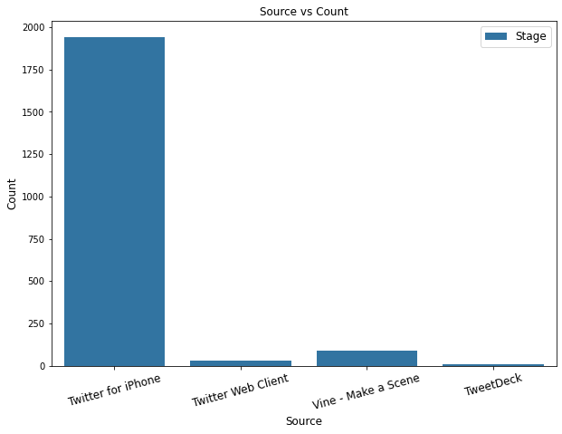

```python
plt.figure(figsize=(10,7))
base_color=sns.color_palette()[0]
sns.countplot(data=df_twitter, x='source', color=base_color)
plt.xticks(rotation=15, size=12)
plt.ylabel("Count", size=12)
plt.xlabel("Source", size=12)
plt.title("Source vs Count", size=12)
plt.legend(["Stage"],fontsize=12);
```

### Observation :

> Clearly the best way to tweet is by phone

2- Which is the most popular dog stage ?

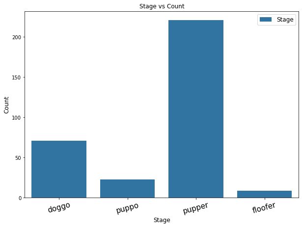

```python
plt.figure(figsize=(10,7))
base_color=sns.color_palette()[0]
sns.countplot(data=df_twitter[df_twitter.Stage.isin(["doggo","puppo","pupper","floofer"])],
              x='Stage', color=base_color)
plt.xticks(rotation=15, size=15)
plt.ylabel("Count", size=12)
plt.xlabel("Stage", size=12)
plt.title("Stage vs Count", size=12)
plt.legend(["Stage"],fontsize=12)
```

### Observation :

> Clearly the most dog stage is pupper, and then doggo

Which type of dog stage got highest favorite and retweet count ?

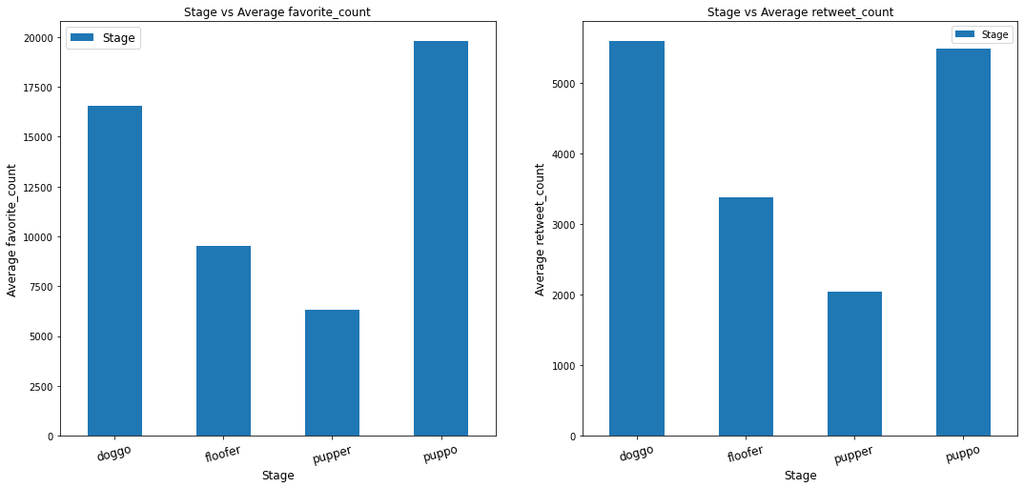

```python
plt.figure(figsize=(18,8))
plt.subplot(1,2,1)
df_twitter[df_twitter.Stage.isin(["doggo","puppo","pupper","floofer"])].groupby(["Stage"]).mean()['favorite_count'].plot(kind='bar')
plt.xticks(rotation=15, size=12)
plt.ylabel("Average favorite_count", size=12)
plt.xlabel("Stage", size=12)
plt.title("Stage vs Average favorite_count", size=12)
plt.legend(["Stage"],fontsize=12)


plt.subplot(1,2,2)
#sns.barplot(data=df_twitter, x='Stage',y='retweet_count',color=base_color,errwidth=0)
df_twitter[df_twitter.Stage.isin(["doggo","puppo","pupper","floofer"])].groupby(["Stage"]).mean()['retweet_count'].plot(kind='bar')
plt.xticks(rotation=15, size=12)
plt.ylabel("Average retweet_count", size=12)
plt.xlabel("Stage", size=12)
plt.title("Stage vs Average retweet_count", size=12)
plt.legend(["Stage"])
plt.show()
```

### Observation :

> Clearly we can see that puppo,doggo have highest favorite and retweet count

Which type of dog stage are most popupular year from year ?

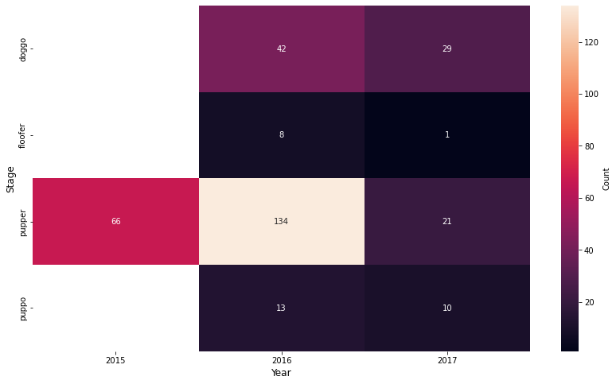

```python
plt.figure(figsize=(14,8))
count_stage_year=df_twitter[df_twitter.Stage.isin(["doggo","puppo","pupper","floofer"])].groupby(["Stage","year"]).size().reset_index(name='Count')
sns.heatmap(count_stage_year.pivot(index = 'Stage', columns = 'year', values = 'Count'),annot = True,fmt = '.0f',
           cbar_kws={'label': 'Count'})
plt.xlabel('Year',size=12)
plt.ylabel('Stage',size=12);
```

### Observation :

> Clearly we can see that the pupper is most popular in 2015,2016 and dogggo is most popular in 2017

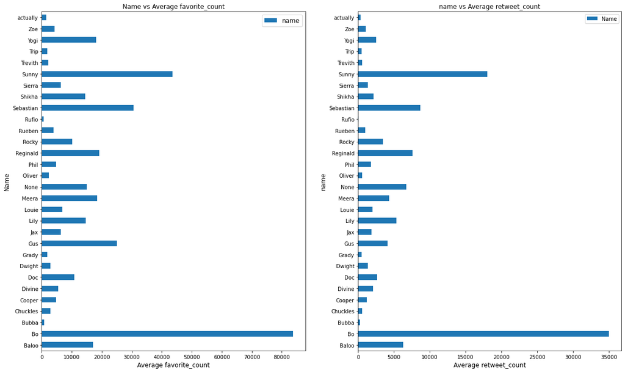

```python
plt.figure(figsize=(20,12))
plt.subplot(1,2,1)
df_twitter[df_twitter.Stage.isin(["doggo","puppo","pupper","floofer"])].sample(50,random_state=1).groupby(["name"]).mean()['favorite_count'].plot(kind='barh')
#plt.xticks(rotation=15, size=12)
plt.xlabel("Average favorite_count", size=12)
plt.ylabel("Name", size=12)
plt.title("Name vs Average favorite_count", size=12)
plt.legend(["name"],fontsize=12)


plt.subplot(1,2,2)

df_twitter[df_twitter.Stage.isin(["doggo","puppo","pupper","floofer"])].sample(50,random_state=1).groupby(["name"]).mean()['retweet_count'].plot(kind='barh')
#plt.xticks(rotation=15, size=12)
plt.xlabel("Average retweet_count", size=12)
plt.ylabel("name", size=12)
plt.title("name vs Average retweet_count", size=12)
plt.legend(["Name"])
plt.show()
```

### Observation:

> We can see clearly that the Bo and sunny name dog are most popular retweet count and favorite count

Which breed of top 217 dogs have most popular prediction in the tweet ?

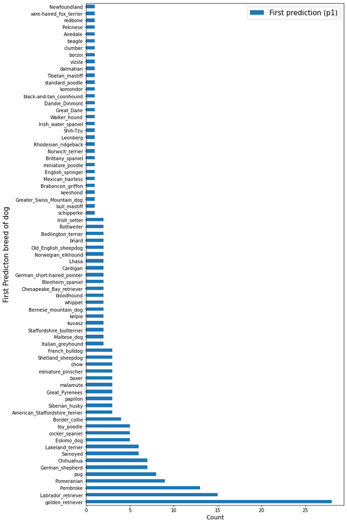

```python
plt.figure(figsize=(10,20))
df[df.Stage.isin(["doggo","puppo","pupper","floofer"])].query("p1_dog==True").p1.value_counts().plot(kind='barh')
plt.ylabel("First Predicton breed of dog",size=15)
plt.legend(["First prediction (p1)"],fontsize=15)
plt.xlabel("Count",size=13);
```

### Observation:

> Clearly the most first prediction breed of dog is Globen_retriever

```python
# return  jpg url for one Globen_retriever breed of dog
df[df.Stage.isin(["doggo","puppo","pupper","floofer"])].query("p1_dog==True and p1=='golden_retriever'").jpg_url.iloc[0]
```

```
'https://pbs.twimg.com/media/DFg_2PVW0AEHN3p.jpg'
```

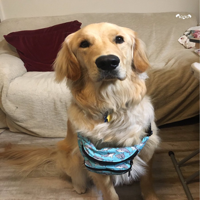

```python
from PIL import Image
from io import BytesIO
import requests
r=requests.get('https://pbs.twimg.com/media/DFg_2PVW0AEHN3p.jpg')

# Example of jpg image of Globen_retriever breed of dog
image=Image.open(BytesIO(r.content))
dog1_img=image.resize((200, 200))
dog1_img
```

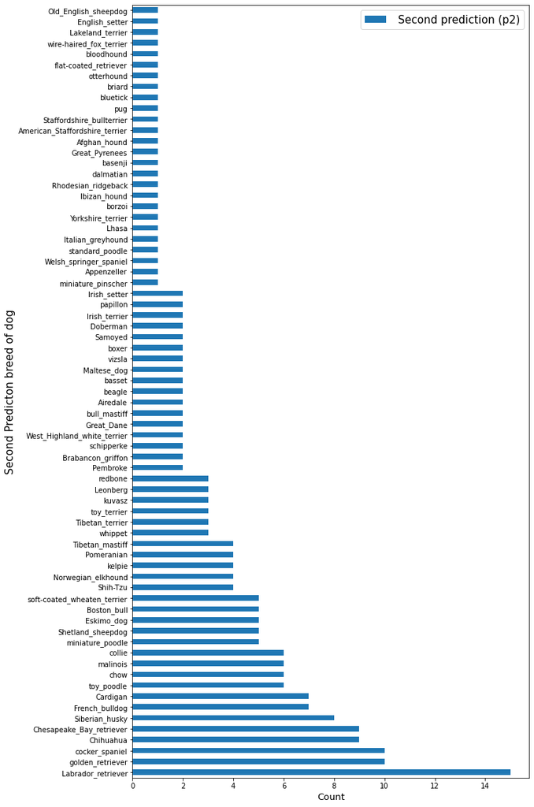

```python
plt.figure(figsize=(10,20))
df[df.Stage.isin(["doggo","puppo","pupper","floofer"])].query("p2_dog==True").p2.value_counts().plot(kind='barh')
plt.ylabel("Second Predicton breed of dog",size=15)
plt.legend([" Second prediction (p2)"],fontsize=15)
plt.xlabel("Count",size=13);
```

### Observation:

> Clearly the most second prediction breed of dog is Labrador_retriever

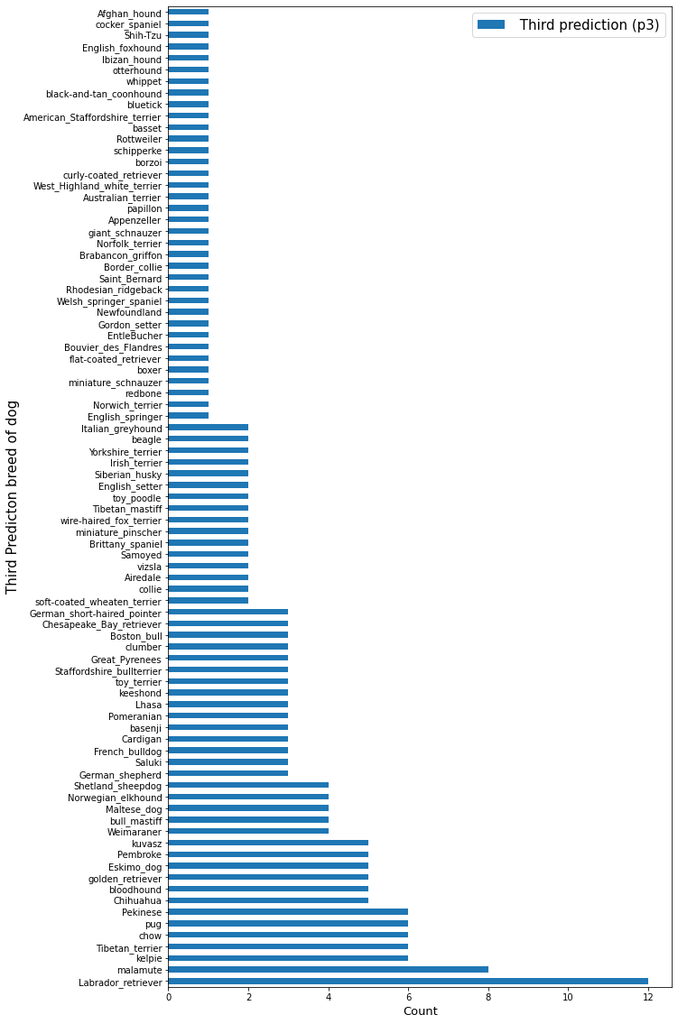

```python
plt.figure(figsize=(10,20))
df[df.Stage.isin(["doggo","puppo","pupper","floofer"])].query("p3_dog==True").p3.value_counts().plot(kind='barh')
plt.ylabel("Third Predicton breed of dog",size=15)
plt.legend([" Third prediction (p3)"],fontsize=15)
plt.xlabel("Count",size=13);
```

### Observation:

> Clearly the most third prediction breed of dog is labrador_retriever

```python
# return  jpg url for one Labrador_retriever breed of dog
df[df.Stage.isin(["doggo","puppo","pupper","floofer"])].query("p3_dog==True and p3=='Labrador_retriever'").jpg_url.iloc[0]
```

```
'https://pbs.twimg.com/media/C-3wvtxXcAUTuBE.jpg'
```

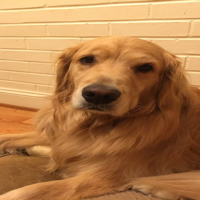

```python
#image jpg for one Labrador_retriever breed of dog
r=requests.get('https://pbs.twimg.com/media/C-3wvtxXcAUTuBE.jpg')
ima=Image.open(BytesIO(r.content))
dog2_img=ima.resize((200, 200))
dog2_img
```

Which breed Top 217 of dog have most favorite count in the case of first the prediction breed of dog?

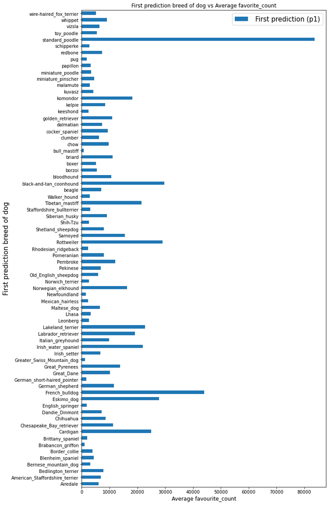

```python
plt.figure(figsize=(10,20))
df[df.Stage.isin(["doggo","puppo","pupper","floofer"])].query("p1_dog==True").groupby(["p1"]).mean()['favorite_count'].plot(kind='barh')
plt.xlabel("Average favourite_count", size=12)
plt.ylabel("First prediction breed of dog", size=15)
plt.title("First prediction breed of dog vs Average favorite_count", size=12)
plt.legend([" First prediction (p1)"],fontsize=15);
```

### Observation:

> Clearly standard poodle dog have most favorite count

```python
# return first jpg url for standard_poodle breed of dog
df[df.Stage.isin(["doggo","puppo","pupper","floofer"])].query("p1=='standard_poodle' and p1_dog==True").jpg_url.iloc[0]
```

```
'https://pbs.twimg.com/media/C12whDoVEAALRxa.jpg'
```

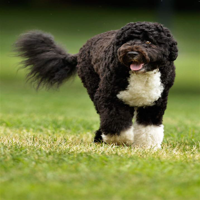

```python
r=requests.get('https://pbs.twimg.com/media/C12whDoVEAALRxa.jpg')
im=Image.open(BytesIO(r.content))
dog3_img=im.resize((200, 200))
dog3_img
```

Which breed top of 217 dogs have most favorite count in the case of second the prediction breed of dog ?

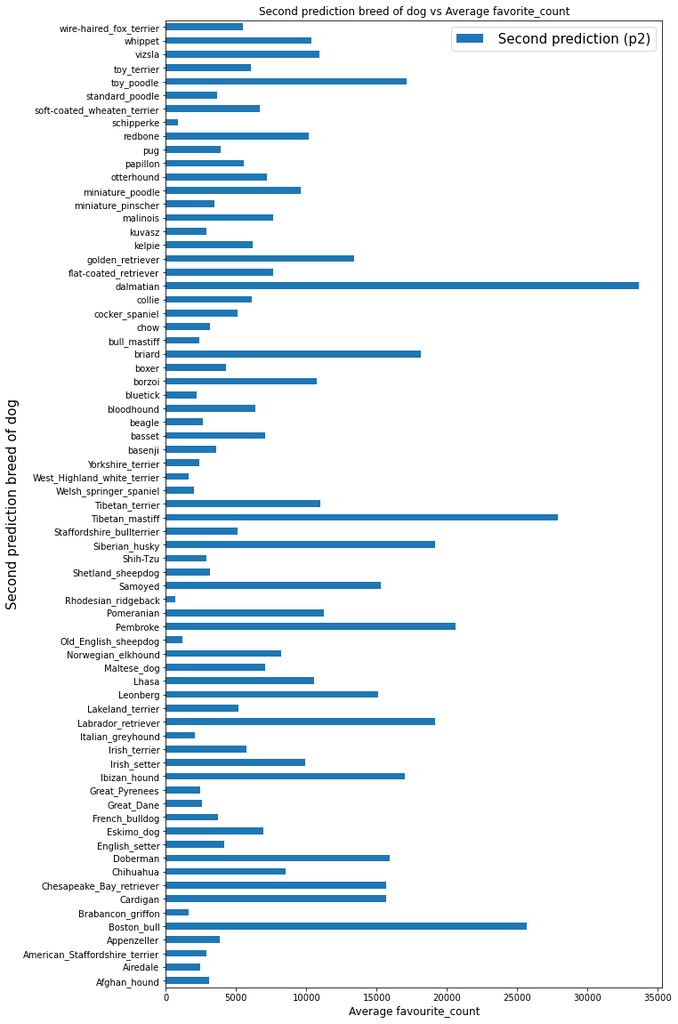

```python
plt.figure(figsize=(10,20))
df[df.Stage.isin(["doggo","puppo","pupper","floofer"])].query("p2_dog==True").groupby(["p2"]).mean()['favorite_count'].plot(kind='barh')
plt.xlabel("Average favourite_count", size=12)
plt.ylabel("Second prediction breed of dog", size=15)
plt.title("Second prediction breed of dog vs Average favorite_count", size=12)
plt.legend([" Second prediction (p2)"],fontsize=15);
```

```python
# return first jpg_url for dalmatain breed of dog
df[df.Stage.isin(["doggo","puppo","pupper","floofer"])].query("p2=='dalmatian' and p2_dog==True").jpg_url.iloc[0]
```

```
'https://pbs.twimg.com/media/CW88XN4WsAAlo8r.jpg'
```

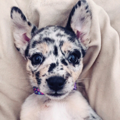

```python
r=requests.get('https://pbs.twimg.com/media/CW88XN4WsAAlo8r.jpg')
img=Image.open(BytesIO(r.content))
dog4_img=img.resize((200, 200))
dog4_img
```

Which breed top of 217 dogs have most favorite count in the case of third the prediction breed of dog ?

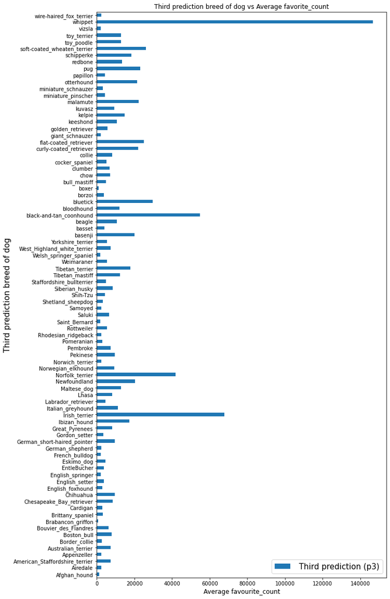

```python
plt.figure(figsize=(10,20))
df[df.Stage.isin(["doggo","puppo","pupper","floofer"])].query("p3_dog==True").groupby(["p3"]).mean()['favorite_count'].plot(kind='barh')
plt.xlabel("Average favourite_count", size=12)
plt.ylabel("Third prediction breed of dog", size=15)
plt.title("Third prediction breed of dog vs Average favorite_count", size=12)
plt.legend([" Third prediction (p3)"],fontsize=15);
```

### Observation:

> Clearly Whippet dog have most favorite count

```python
# return  jpg url for standard_poodle
df[df.Stage.isin(["doggo","puppo","pupper","floofer"])].query("p3=='whippet' and p3_dog==True").jpg_url.iloc[0]
```

```
'https://pbs.twimg.com/ext_tw_video_thumb/744234667679821824/pu/img/1GaWmtJtdqzZV7jy.jpg'
```

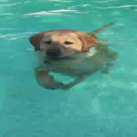

```python
r=requests.get('https://pbs.twimg.com/ext_tw_video_thumb/744234667679821824/pu/img/1GaWmtJtdqzZV7jy.jpg')
imag=Image.open(BytesIO(r.content))
dog4_img=imag.resize((200, 200))
dog4_img
```